# SOK- 2008: Seminar 1

Author

Andrea Mannberg

## Antakelser

Nyttefunksjonen:

$$U(c,l) = c^\alpha \cdot l^\beta$$
Vi antar at: $\alpha = \beta = 0.5$

Antall timer tilgjengelig for jobb per uke: $T = 7 \cdot 12 = 84$

For at figurene skal bli pene definerer vi timelønn og arbeidsfri inntekt i 10-tall kroner
$$m = 100$$
$$w = 2.5$$

## Helle sin budsjettbetingelse

Helles sitt konsum (utgifter) er begrenset av hennes inntekt. Helle har en arbeidsfri inntekt. I tillegg avhenger inntekten hvor mye tid hun legger på arbeid. Denne tiden er begrenset av hvor mye tid hun totalt sett har tilgjengelig, og hvor mye tid hun legger på fritid.

$$m + w \cdot h = c$$
$$T = l + h$$
$$m+w\cdot (T - l) = c$$
## Helle sine indifferansekurver

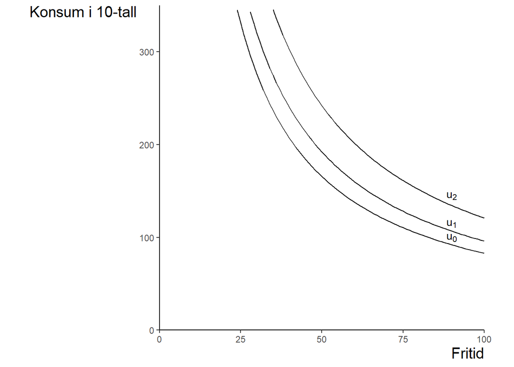

```r
rm(list = ls())

suppressPackageStartupMessages(library(tidyverse))


l_1 <- seq(0, 85, by = .001)


df <- data.frame(l_1)

#lag aksen for tegningen

axes_1 <- ggplot(df, aes(l_1))+
  labs(x="Fritid", y="Konsum i 10-tall") +
  theme(axis.title = element_text(size = 15),
        plot.title = element_text(size = 15),
        panel.background = element_blank(), # hvit bakgrunn
        axis.line = element_line(colour = "black"), # sett inn akselinjer
        axis.title.x = element_text(hjust = 1),
        axis.title.y = element_text(angle = 0, vjust = 1, hjust=1))+ # juster labels på aksene
  coord_fixed(ratio = 1)+ # lik skala for x og y aksen
  scale_x_continuous(limits = c(0, 100), expand = c(0, 0))+
  scale_y_continuous(limits = c(0, 350), expand = c(0, 0))+ # begrense aksene
  coord_fixed(ratio = (100 - 0) / (350 - 0))
# og sikre at akselinjene møttes i (0,0).

# nyttefunkjsonen som brukes U=c^.5x l^.5 (Cobb-Douglas)

# vi angir noen indifferenskurver
I_0 <- function(l_1) (91.03061^2)/(l_1)  # nytte = 91.03061
I_1 <- function(l_1) (98.03061^2)/(l_1) # nytte = 98.03061
I_2 <- function(l_1) (110^2)/(l_1)  # nytte = 110

figur_1 <- axes_1 +
    stat_function(df,
        fun=I_0,
        mapping = aes()
        ) +
  stat_function(df,
        fun=I_1,
        mapping = aes()
        ) +
  stat_function(df,
                fun=I_2,
                mapping = aes()
  ) +
  annotate("text",x=90,y=100, label=expression(u[0]))+
  annotate("text",x=90,y=115, label=expression(u[1]))+
  annotate("text",x=90,y=145, label=expression(u[2]))

figur_1
```

## Helle sin budsjettbetingelse

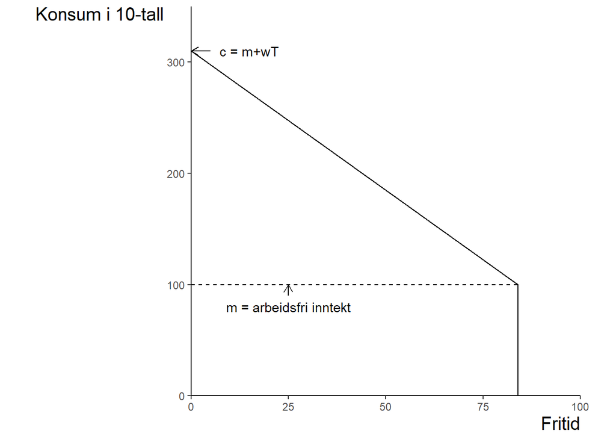

```r
# w=2.5, m=100, T = 84 (7*12) (lønn og arbeidsfri inntekt i ti-tall)
# Budget constraint function
budget_constraint <- function(l_1) {
  return(310 - 2.5 * l_1)
}


figur_2 <- axes_1+
  geom_segment(aes(x = 0, y = budget_constraint(0), xend = 84, yend = budget_constraint(84))) +
  annotate("text",x=15,y=310, label="c = m+wT")+
  geom_segment(aes(x=5, y=310, xend=0, yend=310),
               arrow = arrow(length = unit(0.25, "cm")))+
  geom_segment(aes(x=84, y=0, xend=84, yend=100))+
  geom_segment(aes(x=0, y=100, xend=84, yend=100), linetype="dashed")+
   annotate("text",x=25,y=80, label="m = arbeidsfri inntekt")+
  geom_segment(aes(x=25, y=90, xend=25, yend=100),
               arrow = arrow(length = unit(0.25, "cm")))

figur_2
```

## Helle sin reservasjonslønn

Reservasjonslønna er den laveste lønn som Helle er villig til å aksptere for å ta en jobb. Den laveste lønna vil gjøre Helle indifferent mellom det å jobbe og ikke jobbe. Et annet måte å si dette på er at det optimale valget er $l^* = T$. Vilkåret for $l^* = T$ er at lønna er lik helningen på indifferensekurven der $c = m$ og $l = T$.

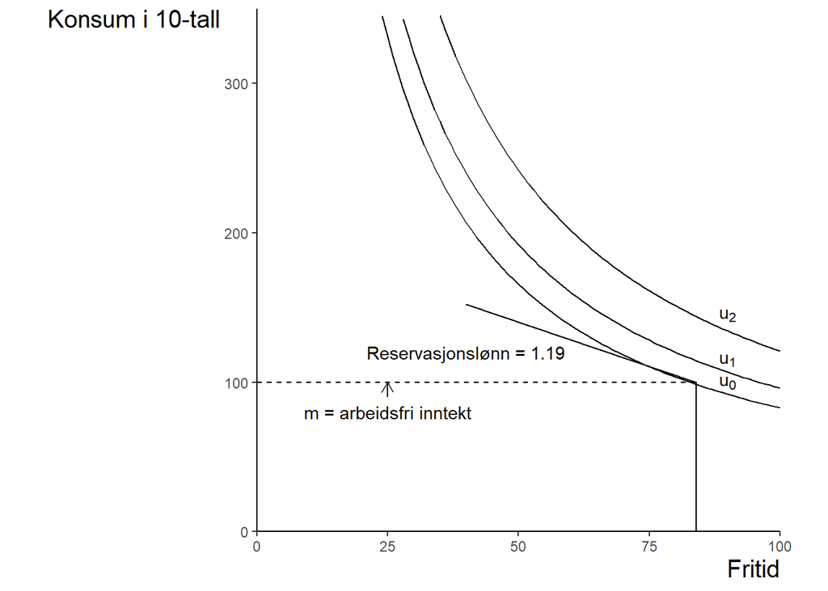

```r
wr <- function(l_1) {
  return(200 - 1.19047619 * l_1)
}

figur_3 <- axes_1+
  stat_function(df,
                fun=I_0,
                mapping = aes()
  )+
  stat_function(df,
                fun=I_1,
                mapping = aes()
  ) +
  stat_function(df,
                fun=I_2,
                mapping = aes()
  )+
  geom_segment(aes(x = 40, y = wr(40), xend = 84, yend = wr(84))) +
  annotate("text",x=90,y=100, label=expression(u[0]))+
  annotate("text",x=90,y=115, label=expression(u[1]))+
  annotate("text",x=90,y=145, label=expression(u[2]))+
  geom_segment(aes(x=84, y=0, xend=84, yend=100))+
  annotate("text",x=40,y=120, label="Reservasjonslønn = 1.19")+
  geom_segment(aes(x=0, y=100, xend=84, yend=100), linetype="dashed")+
  annotate("text",x=25,y=80, label="m = arbeidsfri inntekt")+
  geom_segment(aes(x=25, y=90, xend=25, yend=100),
               arrow = arrow(length = unit(0.25, "cm")))


figur_3
```

## Helle sitt optimale valg av konsum og fritid gitt $w = 2.5$

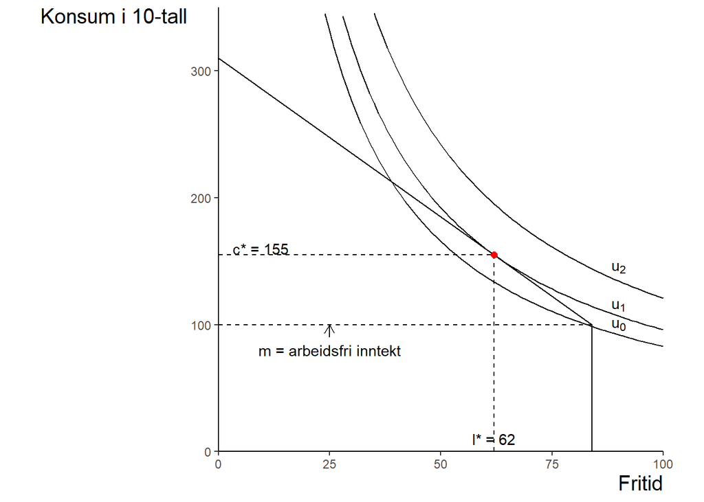

```r
figur_4 <- axes_1+
  stat_function(df,
                fun=I_0,
                mapping = aes()
  )+
  stat_function(df,
                fun=I_1,
                mapping = aes()
  ) +
  stat_function(df,
                fun=I_2,
                mapping = aes()
  )+
  geom_segment(aes(x = 0, y = budget_constraint(0), xend = 84, yend = budget_constraint(84))) +
  annotate("text",x=90,y=100, label=expression(u[0]))+
  annotate("text",x=90,y=115, label=expression(u[1]))+
  annotate("text",x=90,y=145, label=expression(u[2]))+
  geom_segment(aes(x=62, y=0, xend=62, yend=155), linetype="dashed")+
  geom_segment(aes(x=0, y=155, xend=62, yend=155), linetype="dashed")+
  geom_segment(aes(x=62, y=155, xend=61, yend=155))+
  geom_segment(aes(x=84, y=0, xend=84, yend=100))+
  geom_point(aes(x = 62, y = 155), color = "red", size = 2)+
  geom_segment(aes(x=0, y=100, xend=84, yend=100), linetype="dashed")+
  annotate("text",x=25,y=80, label="m = arbeidsfri inntekt")+
  geom_segment(aes(x=25, y=90, xend=25, yend=100),
               arrow = arrow(length = unit(0.25, "cm")))+
  annotate("text",x=62,y=10, label="l* = 62")+
  annotate("text",x=10,y=160, label="c* = 155 ")


figur_4
```

```r
# Løsning l = 62, c =155
```

Intuisjon: Til høyere om A har indifferansekurvene en slakere helning enn budsjettbetingelsen:$-\frac{dc}{dl}\mid_{U = konstant}<w$. $w$ beskriver hvor mye konsum Helle må gi opp dersom hun tar fri én time til. $-\frac{dc}{dl}\mid_{U = konstant}$ er den marginale subsitusjonsbrøken og beskriver hvor mye konsum hun kan gi opp, uten at nytten minker. Dersom Helle velger mer fritid enn $l^*$, må hun gi opp mer konsum enn hun er villig til å gjøre. Nytten reduseres.

Til venstre om A har indifferansekurvene en brattere helning enn budsjettbetingelsen $-\frac{dc}{dl}\mid_{U = konstant}>w$ . Dersom Helle jobber flere timer får hun mindre konsum ($w$) enn hun trenger for å holde nytten konstant. Nytten reduseres. I A kan Helle ikke øke sin nytte ved å endre kombinasjonen av $c$ og $l$.

## Inntekts og substitusjonseffekter

```r
#lag aksen for tegningen

axes_2 <- ggplot(df, aes(l_1))+
  labs(x="Fritid", y="Konsum i 10-tall") +
  theme(axis.title = element_text(size = 15),
        plot.title = element_text(size = 15),
        panel.background = element_blank(), # hvit bakgrunn
        axis.line = element_line(colour = "black"), # sett inn akselinjer
        axis.title.x = element_text(hjust = 1),
        axis.title.y = element_text(angle = 0, vjust = 1, hjust=1))+ # juster labels på aksene
  coord_fixed(ratio = 1)+ # lik skala for x og y aksen
  scale_x_continuous(limits = c(0, 100), expand = c(0, 0))+
  scale_y_continuous(limits = c(0, 400), expand = c(0, 0))+ # begrense aksene
  coord_fixed(ratio = (100 - 0) / (400 - 0))
# og sikre at akselinjene møttes i (0,0).

# nyttefunkjsonen som brukes U=c^.5x l^.5 (Cobb-Douglas)

# vi angir noen indifferenskurver
I_0 <- function(l_1) (91.03061^2)/(l_1)  # nyttenivå 28.98275
I_1 <- function(l_1) (98.03061^2)/(l_1) # nytte=29.96331
I_2 <- function(l_1) (102.5305^2)/(l_1)  # nytte =40
I_3 <- function(l_1) (110^2)/(l_1)  # nytte =40
```

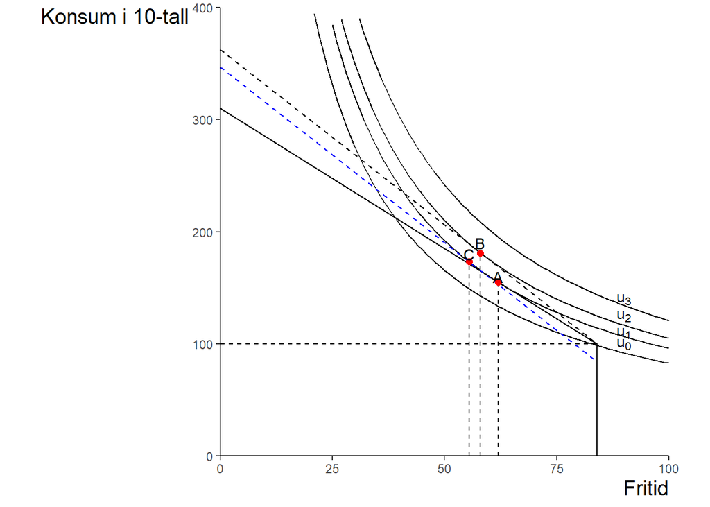

```r
budget_constraint <- function(l_1) {
  return(310 - 2.5 * l_1)
}

budget_1 <- function(l_1) {
  return(362.5 - 3.125 * l_1)
}
budget_2 <- function(l_1) {
  return(346.61- 3.125 * l_1)
}


figur_5 <- axes_2+
  stat_function(df,
                fun=I_0,
                mapping = aes()
  )+
  stat_function(df,
                fun=I_1,
                mapping = aes()
  ) +
  stat_function(df,
                fun=I_2,
                mapping = aes()
  )+
    stat_function(df,
                fun=I_3,
                mapping = aes()
  )+
  geom_segment(aes(x = 0, y = budget_constraint(0), xend = 84, yend = budget_constraint(84))) +
  geom_segment(aes(x = 0, y = budget_1(0), xend = 84, yend = budget_1(84)), linetype = "dashed") +
  geom_segment(aes(x = 0, y = budget_constraint(0), xend = 84, yend = budget_constraint(84))) +
  geom_segment(aes(x = 0, y = budget_2(0), xend = 84, yend = budget_2(84)), linetype = "dashed", color = "blue") +
  annotate("text",x=90,y=100, label=expression(u[0]))+
  annotate("text",x=90,y=110, label=expression(u[1]))+
  annotate("text",x=90,y=125, label=expression(u[2]))+
  annotate("text",x=90,y=140, label=expression(u[3]))+
  geom_segment(aes(x=62, y=0, xend=62, yend=155), linetype="dashed")+
  geom_segment(aes(x=58, y=0, xend=58, yend=181.25), linetype="dashed")+
  geom_segment(aes(x=55.45759, y=0, xend=55.45759, yend=173.305), linetype="dashed")+
  geom_segment(aes(x=84, y=0, xend=84, yend=100))+
  geom_point(aes(x = 62, y = 155), color = "red", size = 2)+
  geom_point(aes(x = 58, y = 181.25), color = "red", size = 2)+
  geom_point(aes(x = 55.45759, y = 173.305), color = "red", size = 2)+
  annotate("text",x=62,y=160, label= "A")+
  annotate("text",x=58,y=190, label= "B")+
  annotate("text",x=55.45759,y=180, label= "C")+
  geom_segment(aes(x=0, y=100, xend=84, yend=100), linetype="dashed")


figur_5
```

- Nytt optimalt valg: B ($c_2^*,l_2^*$).
- Subsitusjonseffekt: A til C; $l_1^* \rightarrow l_2^s$
- Inntektseffekt: C til B; $l_2^s \rightarrow l_2^*$

*Intuisjon*: En høyere lønn fører til at alternativkostnaden for å ha fri øker. Dersom Helle tar fri én time går hun glipp av mer konsum enn tidligere. Dette gir henne insentiver til å jobbe flere timer. Dette gir intuisjon til substitusjonseffekten.

En høyere lønn fører til at Helle kan konsumere mer ved et gitt antall arbeidstimer. Hun kan også beholde samme nivå av konsum, selv om hun reduserer mengden arbeidstimer. Helle har med andre ord råd å ha mer fri. Dersom fritid er et normalt gode vil dette gi henne insentiver til å minke arbeidstilbudet. Dette gir intuisjon til inntektseffekten.

## Helle sitt arbeidstilbud

### Matematisk utledning

$$maks_{c,l,\lambda}{\mathcal{L}} = c^\alpha \cdot l^\beta +\lambda (m+w\cdot (T-l))$$
Første ordningens vilkår for nyttemaks:
$$\frac{\partial \mathcal{L}}{\partial c}=0; \alpha \cdot c^{\alpha -1}\cdot l^\beta -\lambda =0$$
$$\frac{\partial \mathcal{L}}{\partial l}=0; \beta \cdot c^{\alpha}\cdot l^{\beta-1} -\lambda \cdot w =0$$
$$\frac{\partial \mathcal{L}}{\partial \lambda}=0; m+w\cdot (T-l) =0$$
Vi bruker første ordningens vilkår for $c$ og $l$ til å ta fram $c$ som en funksjon av $l$ og setter in den i første ordningens vilkår for $\lambda$
$$\frac{\alpha \cdot c^{\alpha -1}\cdot l^\beta}{\beta \cdot c^{\alpha}\cdot l^{\beta-1} }=\frac{\lambda}{\lambda \cdot w}$$
Ved å forenkle får vi:
$$\frac{\alpha \cdot l}{\beta \cdot c}=\frac{1}{w}$$
$$c = \frac{\alpha}{\beta}\cdot w\cdot l$$
$$m+w\cdot (T-l) = \frac{\alpha}{\beta}\cdot w\cdot l$$
$$m +wT= w\cdot l \cdot (\frac{\alpha}{\beta}+1)$$
$$m +wT= w\cdot l \cdot (\frac{\alpha + \beta}{\beta})$$
$$l^* = \frac{\beta}{\alpha +\beta }\cdot (\frac{m}{w}+T)$$
$$h^* = T-l^*$$
$$h^* = T-\frac{\beta}{\alpha +\beta }\cdot (\frac{m}{w}+T)$$
$$h^* = \frac{\alpha}{\alpha +\beta}\cdot T-\frac{\beta}{\alpha +\beta }\cdot \frac{m}{w}$$
*Intuisjonssjekk:* 1) teste hva som skjer med arbeidstilbudet dersom lønna øker. Vi forventer oss enten en positiv effekt, eller at vi ser en positiv effekt (substitusjonseffekt) og en negativ effekt (inntektseffekt). 2) teste hva som skjer dersom arbeidsfri inntekt øker. Vi forventer oss at arbeidstilbudet vil være mindre, jo høyere m er.

For å tegne inn arbeidstilbudet i en graf må først se hvilken lønn som gir $h^*=0$ (reservasjonslønna til Helle).

$$0 = \frac{\alpha}{\alpha +\beta}\cdot T-\frac{\beta}{\alpha +\beta }\cdot \frac{m}{w^r}$$
$$\frac{\alpha}{\alpha +\beta}\cdot T = \frac{\beta}{\alpha +\beta }\cdot \frac{m}{w^r}$$
$$(\frac{\alpha}{\alpha +\beta}) \cdot (\frac{\alpha+\beta}{\beta})\cdot \frac{T}{m} = \frac{1}{w^r}$$
$$\frac{\alpha}{\beta}\cdot \frac{T}{m} = \frac{1}{w^r}$$
$$w^r = \frac{\beta}{\alpha}\cdot \frac{m}{T}$$
Vi ser at, jo høyere arbeidsfri inntekt Helle har, desto høyere må timelønna være for at hun skal være villig å jobbe i det hele tatt. Vi ser også at, jo mer Helle vurderer fritid ($\beta$), desto høyere vil reservasjonslønna være.

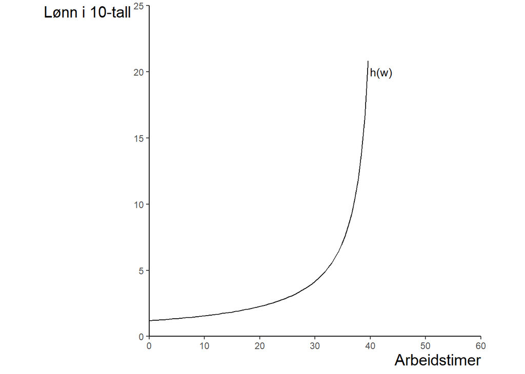

```r
# vi lager oss noen tall for fritids-variabelen (h_1)

h_1 <- seq(0, 50, by = .001)

# gjør om til data frame

df_1 <- data.frame(h_1)

#lag aksen for tegningen

hours <- ggplot(df_1, aes(h_1))+
  labs(x="Arbeidstimer", y="Lønn i 10-tall") +
  theme(axis.title = element_text(size = 15),
        plot.title = element_text(size = 15),
        panel.background = element_blank(), # hvit bakgrunn
        axis.line = element_line(colour = "black"), # sett inn akselinjer
        axis.title.x = element_text(hjust = 1),
        axis.title.y = element_text(angle = 0, vjust = 1, hjust=1))+ # juster labels på aksene
  coord_fixed(ratio = 1)+
  scale_x_continuous(limits = c(0, 60), expand = c(0, 0))+
  scale_y_continuous(limits = c(0, 25), expand = c(0, 0))+ # begrense aksene
  coord_fixed(ratio = (60 - 0) / (25 - 0))
# og sikre at akselinjene møttes i (0,0).

# nyttefunkjsonen som brukes U=c^.5x l^.5 (Cobb-Douglas)

# vi angir funksjonen til arbeidstilbudet
ls <- function(h_1) (0.5*100)/(0.5*84-h_1)

figur_8 <- hours +
    stat_function(df_1,
        fun=ls,
        mapping = aes()
        ) +
  annotate("text",x=42,y=20, label= "h(w)")

figur_8
```